# 04_Modelo_base_Binomial_Trees_Logistic_Regression

## 5. **Aplicación de Modelos**

### Modelos básicos

Comenzamos con el modelado. El problema que se presenta es predecir los fraudes en la apertura de cuentas bancarias en línea. Basándonos en un esquema de la siguiente fuente: https://blogs.sas.com/content/subconsciousmusings/2020/12/09/machine-learning-algorithm-use/, hemos llegado a la conclusión de que el principal objetivo es predecir un número, aplicando modelos de regresión y haciendo uso de modelos de clasificación en función de los resultados, dentro del aprendizaje supervisado.

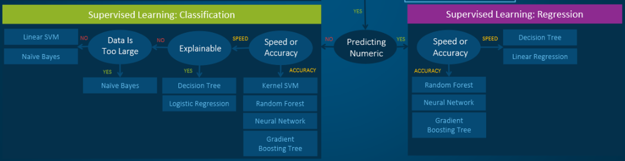

Por tanto, comenzaremos con los modelos más sencillos, e iremos aplicando los modelos en función del incremento de su complejidad y el tiempo de cómputo, con el fin de comprobar si puede ir acorde a los resultados obtenidos.

Modelos aplicados:

1. Modelo base
2. Arbol de clasificación
3. Regresión logística

### Librerías

```python
from sklearn.linear_model import LogisticRegression
from sklearn.tree import DecisionTreeClassifier, plot_tree
from sklearn import tree
from sklearn.metrics import classification_report
from funciones_metricas import *

import matplotlib.pyplot as plt
import numpy as np
import pandas as pd
import seaborn as sns
import scikitplot as skp

import warnings
warnings.filterwarnings('ignore')
```

### Carga de datos

```python
path_folder = "./"
x_train_1 = pd.read_csv(path_folder +"Xtrain1_data.csv", low_memory=False)
x_val = pd.read_csv(path_folder +"Xval_data.csv", low_memory=False)

y_train_1 = pd.read_csv(path_folder +"ytrain1_data.csv", low_memory=False)
y_val = pd.read_csv(path_folder +"yval_data.csv", low_memory=False)
```

Se cargan los datos nombrando a las variables según su uso: entrenamiento o validación y la división ya realizada en previos notebooks. Según la documentación PEP8, el nombre de las variables sigue el estilo snake_case.

Fuente: https://peps.python.org/pep-0008/

### Aplicación de métricas

Haremos uso de las principales métricas para poder comparar cada modelo. Por otro lado, explicaremos por qué no hemos hecho uso de otras. Las funciones de las métricas aplicadas se encuentran en un archivo formato .py a través del cual se van importando en los diferentes notebooks. Por otro lado, hemos mantenido las funciones de los modelos para que se pueda apreciar claramente su ejecución.

· **Métricas empleadas**

1. Matriz de confusión, normalizada y sin normalizar: muestra una visión detallada de los aciertos y errores del modelo.
2. Accuracy: permite conocer una medida general de la exactitud de predicción del modelo.
3. Curva ROC: se puede evaluar el rendimiento en diferentes umbrales de clasificación.
4. Precisión, Recall y F1-Score: en relación con la curva ROC, se puede evaluar el equilibrio entre la precisión y exhaustividad del mismo.

· **Otras métricas**

1. Curva de ganancia acumulativa
2. Curva Lift

En este caso, este tipo de métricas no se han aplicado para comparar modelos, puesto que, por su definición matemática, se encuentran más dedicadas a la puesta en producción del modelo que se vaya a utilizar para realizar la predicción.

1. Partial Dependence Plots: esta herramienta gráfica permite una representación visual de la relación entre una variable específica y la predicción de un modelo, mientras que se mantienen constantes el resto de variables.

Por tanto, esta métrica no ha sido empleada durante la comparación de modelos puesto que el objetivo es más general, ya que se quiere comprobar cómo de bueno es cada modelo para predecir el fraude, no variables en específico y su relación con la variable objetivo.

Fuente: https://scikit-learn.org/stable/modules/partial_dependence.html

### **1. Modelo base**

En este trabajo partimos de una clasificación binaria: predecir si hay fraude o no en la apertura de cuentas bancarias en línea. Por tanto, el modelo consiste en predecir asignando siempre el mismo valor, que será el valor mayoritario en el target. Esto resulta útil por dos motivos:

1. El dataset tiene una variable objetivo (fraud_bool) que se encuentra muy desbalancedada. Aún así, en el preprocesamiento del Notebook 3 se realiza undersampling, lo que ayuda a balancear los datos.
2. Se consigue un valor de referencia del que se puede partir para mejorar, al ver cuántos resultados es capaz de predecir a partir del resultado mayoritario (fraud_bool = 0).

#### 1.1 Inspección de datos

```python
 y_train_1.head()
```

|  | fraud_bool |
| --- | --- |
| 0 | 0 |
| 1 | 0 |
| 2 | 0 |
| 3 | 0 |
| 4 | 0 |

Se hace uso de la variable objetivo buleana que se va a entrenar en los modelos.

#### 1.2 Modelado

```python
%%time
def modelo_base(y_train_1, fraud_bool):
    if fraud_bool not in y_train_1.columns:
        raise ValueError(f"La variable '{fraud_bool}' no existe en el DataFrame.")

    if set(y_train_1[fraud_bool]) != {0, 1}:
        raise ValueError(f"La variable '{fraud_bool}' no contiene solo los valores 0 y 1.")

    # Calcula el valor más común (el que más se repite) en la variable
    valor_mas_comun = y_train_1[fraud_bool].mode().iloc[0]

    # Agrega una nueva columna al DataFrame con el valor más común
    y_train_1['Prediccion'] = valor_mas_comun

    return y_train_1
```

```
CPU times: total: 0 ns
Wall time: 1.04 ms
```

```python
modelo_base(y_train_1, 'fraud_bool')
```

|  | fraud_bool | Prediccion |
| --- | --- | --- |
| 0 | 0 | 0 |
| 1 | 0 | 0 |
| 2 | 0 | 0 |
| 3 | 0 | 0 |
| 4 | 0 | 0 |
| ... | ... | ... |
| 14205 | 1 | 0 |
| 14206 | 1 | 0 |
| 14207 | 1 | 0 |
| 14208 | 1 | 0 |
| 14209 | 1 | 0 |

14210 rows × 2 columns

```python
y_train = y_train_1['fraud_bool']
y_pred = y_train_1['Prediccion']
```

```python
y_pred.head
```

```
<bound method NDFrame.head of 0        0
1        0
2        0
3        0
4        0
        ..
14205    0
14206    0
14207    0
14208    0
14209    0
Name: Prediccion, Length: 14210, dtype: int64>
```

Este modelo base es capaz de predecir la clase más común o, dicho de otra forma, el valor que más se repite con la variable 'fraud_bool'. Como los datos se encuentran balanceados, se obtendrá un punto de partida para mejorar en base a este resultado.

#### Evaluación del modelo

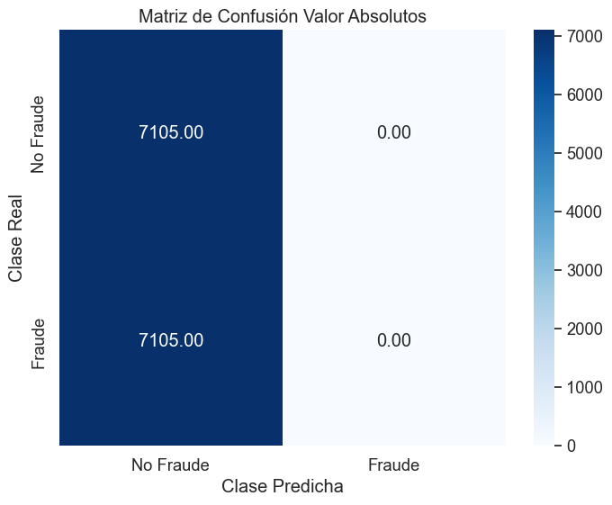

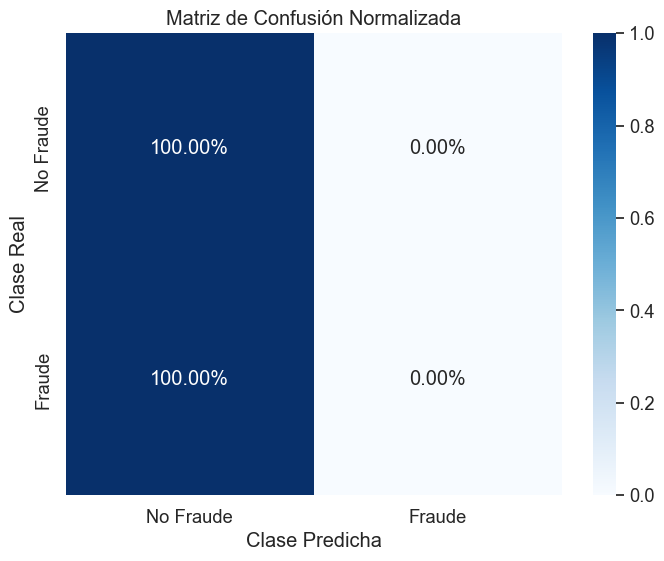

```python
plot_confusion_matrices(y_train, y_pred)
```

Como los datos de la variable objetivo se encuentran balanceados a través de un undersampling, se obtiene una matriz de confusión que es capaz de predecir con un 50% de aciertos. Detecta perfectamente los que predice como no fraude y son, en la realidad, no fraude.

Por otro lado se puede apreciar cómo no es capaz de detectar aquellos que son fraude realmente porque en el modelo base solo se ha hecho la predicción con la clase mayoritaria.

Esta métrica también permite detectar la gravedad de los errores a la hora de realizar la predicción en el modelo.

1. Error de Tipo 1 (Falso Positivo): Este error puede llevar a inconvenientes para los clientes cuyas transacciones legítimas son clasificadas erróneamente como fraudulentas. Puede resultar en bloqueos de tarjetas o cuentas, lo que genera molestias y pérdida de confianza del cliente en el servicio.
2. Error de Tipo 2 (Falso Negativo): Este error resulta más grave desde el punto de vista de la seguridad. Si el modelo no detecta un fraude, puede tener consecuencias financieras significativas para el cliente y el banco. El fraude no detectado podría resultar en pérdidas económicas y dañar la reputación del banco.

Por tanto, consideramos que en este caso, el Error tipo 2 puede desembocar en consecuencias más graves tanto en términos monetarios como de seguridad, por lo que será necesario vigilar los niveles de sensibilidad o recall.

```python
calcular_accuracy_score(y_train, y_pred)
```

```
0.5
```

El accuracy por tanto, muestra un resultado que reafirma aquellos obtenidos en la matriz de confusión.

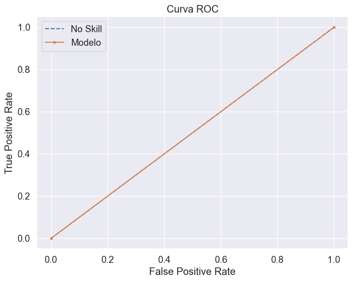

```python
plot_roc_curve(y_train, y_pred)
```

La curva ROC muestra cómo se parte de un threshold mínimo como es el 50%. Por tanto esta curva nos ayuda a entender que aquellos modelos que se encuentren por encima de ese threshold están mejor entrenados para predecir el fraude.

```
Best Threshold=0.000, F1-Score=0.667
```

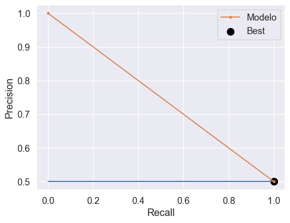

```
F-Score: 0.00000
```

```
(0, 0.6666666666666666)
```

```python
evaluar_modelo_precision_recall(y_train, y_pred)
```

```python
print(classification_report(y_train, y_pred))
```

```
              precision    recall  f1-score   support

           0       0.50      1.00      0.67      7105
           1       0.00      0.00      0.00      7105

    accuracy                           0.50     14210
   macro avg       0.25      0.50      0.33     14210
weighted avg       0.25      0.50      0.33     14210
```

### **2. Árbol de clasificación - Decision Trees**

Los árboles de decisión (DT) son un método de aprendizaje supervisado no paramétrico que utilizaremos, en este caso, para clasificación. Nuestro objetivo es crear un modelo capaz de predecir el valor de una variable objetivo, aprendiendo reglas de decisión simples, inferidas de las características de los datos. Se usa el árbol de clasificación binomial por los siguientes motivos:

1. Fácil de entender e interpretar.
2. Puede manejar datos numéricos.

Fuente: https://scikit-learn.org/stable/modules/tree.html

#### 2.1 Inspección de datos

```python
y_train_1.shape
```

```
(14210, 2)
```

```python
x_train = x_train_1
x_train.shape
```

```
(14210, 50)
```

#### 2.2 Modelado

```python
#Entrenamiento
modelo_arbol = tree.DecisionTreeClassifier()
modelo_arbol = modelo_arbol.fit(x_train, y_train)
```

[output not shown]

```
[Text(0.6158255879211573, 0.9821428571428571, 'x[13] <= 0.882\ngini = 0.5\nsamples = 14210\nvalue = [7105, 7105]'),
 ...]
```

[figure not shown]

```python
%%time
tree.plot_tree(modelo_arbol)
```

```python
# Predicción
y_pred = modelo_arbol.predict(x_val)
y_pred_prob = modelo_arbol.predict_proba(x_val)
```

#### 2.3 Evaluación del modelo

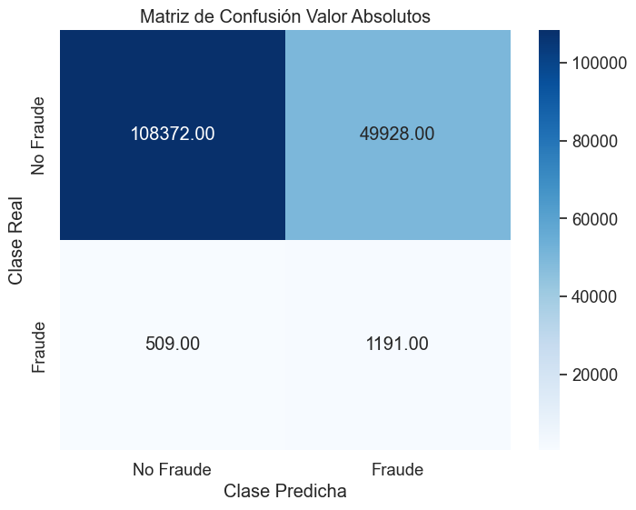

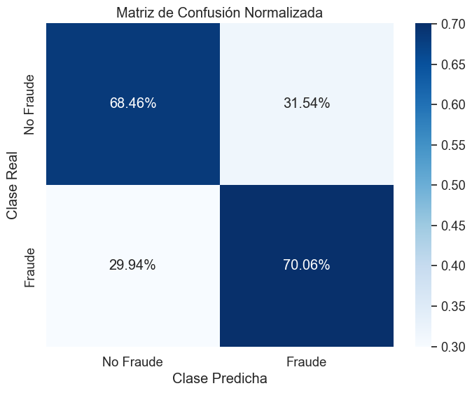

```python
plot_confusion_matrices(y_val, y_pred)
```

```python
calcular_accuracy_score(y_val, y_pred)
```

```
0.68476875
```

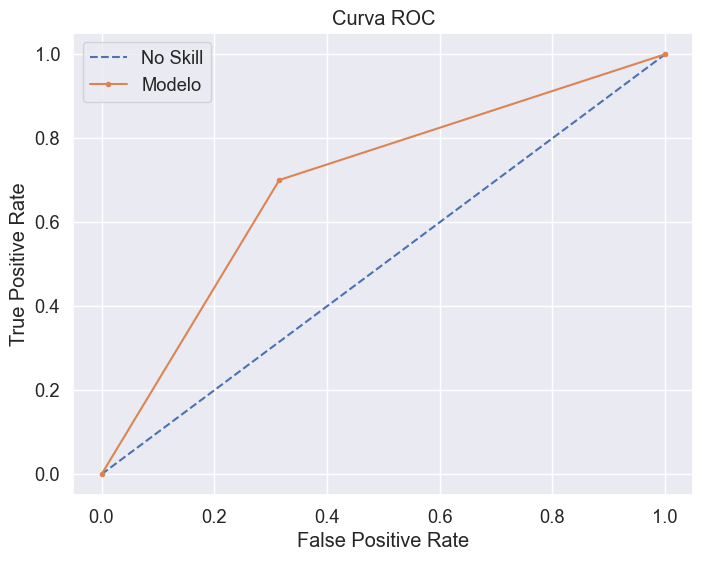

```python
plot_roc_curve(y_val, y_pred)
```

En comparación con el modelo base, la curva ROC presenta una mejora del entrenamiento del modelo haciendo uso de árboles binomiales.

```
Best Threshold=1.000, F1-Score=0.045
```

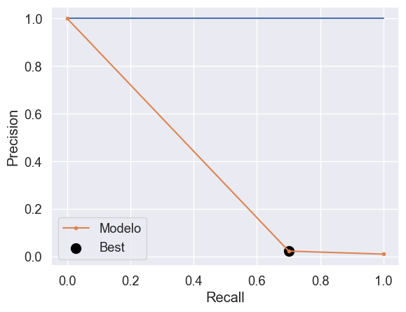

```
F-Score: 0.04510
```

```
(1, 0.04509740812965031)
```

```python
evaluar_modelo_precision_recall(y_val, y_pred)
```

En este caso el F-score presenta unos resultados pequeños, obteniendo así un F-Score=0.045. Esto muestra cómo, para balancear entre precisión y sensibilidad, habría que poner un mayor enfoque en la precisión, puesto que para la detección del fraude se tiene que poner más enfoque en la detección de fraude (valor = 1).

```python
print(classification_report(y_val, y_pred))
```

```
              precision    recall  f1-score   support

           0       1.00      0.68      0.81    158300
           1       0.02      0.70      0.05      1700

    accuracy                           0.68    160000
   macro avg       0.51      0.69      0.43    160000
weighted avg       0.98      0.68      0.80    160000
```

### 3. Regresión logística

El objetivo de este tipo de modelos es tratar la clasificación binaria de forma eficaz, donde el objetivo es predecir la pertenencia a una de las dos clases: fraude o no, en este caso. Se hace uso de una función sigmoide que representa la probabilidad entre 0 y 1. La regresión logística es aplicable en este problema por los siguientes motivos:

1. Interpretabilidad: los coeficientes de la regresión logística proporcionan una interpretación de cómo cada característica afecta las probabilidades de la clase positiva (existe fraude). Esto hace que el modelo sea fácil de entender y explicar.
2. Manejo de probabilidades: la regresión logística predice probabilidades y no solo clases, lo que proporciona información adicional sobre la confianza del modelo en sus predicciones.

#### 3.1 Inspección de datos

```python
x_train.head()
```

|  | cluster | payment_type_AA | payment_type_AB | payment_type_AC | payment_type_AD | payment_type_AE | employment_status_CA | employment_status_CB | employment_status_CC | employment_status_CD | ... | has_other_cards | proposed_credit_limit | foreign_request | session_length_in_minutes | keep_alive_session | device_distinct_emails_8w | month | address_months_total | email_similarity_binary | income_times_age |
| --- | --- | --- | --- | --- | --- | --- | --- | --- | --- | --- | --- | --- | --- | --- | --- | --- | --- | --- | --- | --- | --- |
| 0 | 2 | -0.590132 | 1.304404 | -0.580936 | -0.367381 | -0.01681 | 0.607801 | -0.40024 | -0.198245 | -0.165085 | ... | -0.535176 | -0.647751 | -0.161164 | -0.447130 | 0.855854 | -0.100844 | -0.583487 | 1.359557 | 0.315382 | 0.825027 |
| 1 | 3 | 1.694535 | -0.766633 | -0.580936 | -0.367381 | -0.01681 | 0.607801 | -0.40024 | -0.198245 | -0.165085 | ... | -0.535176 | -0.647751 | -0.161164 | -0.369173 | 0.855854 | -0.100844 | 0.321531 | -0.952983 | 0.315382 | 1.603001 |
| 2 | 3 | 1.694535 | -0.766633 | -0.580936 | -0.367381 | -0.01681 | 0.607801 | -0.40024 | -0.198245 | -0.165085 | ... | -0.535176 | -0.647751 | -0.161164 | -0.317346 | 0.855854 | 5.437772 | -1.488504 | -0.666778 | 0.315382 | 0.825027 |
| 3 | 8 | -0.590132 | 1.304404 | -0.580936 | -0.367381 | -0.01681 | -1.645275 | -0.40024 | -0.198245 | -0.165085 | ... | -0.535176 | -0.647751 | -0.161164 | -0.204811 | -1.168423 | -0.100844 | -1.488504 | 0.420803 | -3.170756 | -1.119908 |
| 4 | 9 | 1.694535 | -0.766633 | -0.580936 | -0.367381 | -0.01681 | 0.607801 | -0.40024 | -0.198245 | -0.165085 | ... | -0.535176 | -0.647751 | -0.161164 | -0.503445 | 0.855854 | -0.100844 | 1.679057 | -0.506502 | -3.170756 | 0.358243 |

5 rows × 50 columns

```python
y_train = y_train_1.drop('Prediccion', axis=1)
y_train
```

|  | fraud_bool |
| --- | --- |
| 0 | 0 |
| 1 | 0 |
| 2 | 0 |
| 3 | 0 |
| 4 | 0 |
| ... | ... |
| 14205 | 1 |
| 14206 | 1 |
| 14207 | 1 |
| 14208 | 1 |
| 14209 | 1 |

14210 rows × 1 columns

#### 3.2 Modelado

```python
# Entrenamiento
modelo_logistico = LogisticRegression(random_state=0)
modelo_logistico.fit(x_train, y_train)
```

```
LogisticRegression(random_state=0)
```

En este modelo se hace uso de el parámetro random_state = 0, con el fin de garantizar la reproducibilidad de los resultados, un aspecto fundamental en el modelado predictivo. Es por ello que la elección de este valor no presenta un impacto en la calidad del modelo, asegurando la obtención de resultados consistentes cada vez que el código sea ejecutado.

```python
# Predicción
predicciones_val = modelo_logistico.predict(x_val)
predicciones_val
```

```
array([0, 1, 0, ..., 0, 0, 0], dtype=int64)
```

```python
score_val = modelo_logistico.score(x_val, y_val)
score_val
```

```
0.7969125
```

#### 3.3 Evaluación del modelo

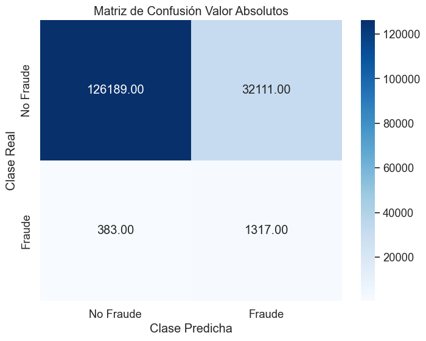

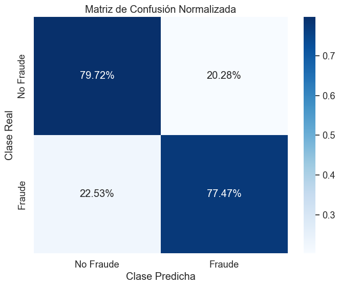

```python
plot_confusion_matrices(y_val, predicciones_val)
```

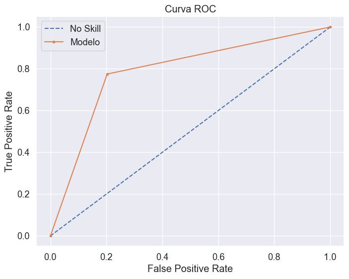

```python
plot_roc_curve(y_val, predicciones_val)
```

La curva ROC presenta una mejora en la predicción en comparación con la realidad. Se cuenta con una tasa de verdaderos positivos cercana a un 80%.

```
Best Threshold=1.000, F1-Score=0.075
```

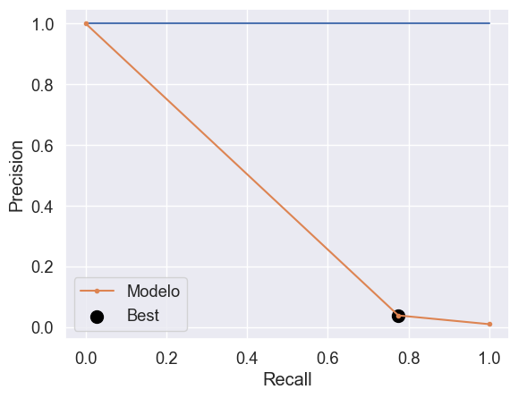

```
F-Score: 0.07498
```

```
(1, 0.07498291960828968)
```

```python
evaluar_modelo_precision_recall(y_val, predicciones_val)
```

El F-score muestra unos resultados que permiten poner un mayor enfoque en la precisión para la detección de las cuentas bancarias fraudulentas (F-Score=0.075).

```python
print(classification_report(y_val, predicciones_val))
```

```
              precision    recall  f1-score   support

           0       1.00      0.80      0.89    158300
           1       0.04      0.77      0.07      1700

    accuracy                           0.80    160000
   macro avg       0.52      0.79      0.48    160000
weighted avg       0.99      0.80      0.88    160000
```

## Conclusiones

1. Los mejores resultados de predicción sitúan al modelo de **Regresión Logística** como el más eficiente en términos de clasificación para detectar fraude.
2. En los modelos desarrollados en este notebook se puede apreciar cómo hay que poner un mayor enfoque en la precisión.